# 第4章 基本数据管理

武汉大学经济与管理学院  
刘开军 博士  
Email: kjliu@whu.edu.cn

## 预备知识

- 算术运算
- 集合运算
- 逻辑运算
- 用逻辑向量进行筛选
- 缺失值
- 向量的修改
- 循环补齐规则

## 算术运算

R中常用的算术运算符包括：

| 运算符 | 功能 |
| --- | --- |
| `+, -, *, /` | 加、减、乘、除 |
| `^或**` | 幂，例如：`2^4`的结果为16，`2**0.5`的结果是1.414214 |
| `%%` | 求余数，例如：`5%%2`的结果为1 |
| `%/%` | 求商（整数），例如：`6.5%/%2.7`的结果为2 |

以上运算符可以对标量进行运算，也可以对向量进行运算。**向量运算的结果仍然是向量。**

```r
a <- c(1:10); b <- c(2, 5)
a/2
```

```
##  [1] 0.5 1.0 1.5 2.0 2.5 3.0 3.5 4.0 4.5 5.0
```

```r
a/b  #分子依次取1,2,...,10；分母依次取2,5,2,5,...
```

```
##  [1] 0.5 0.4 1.5 0.8 2.5 1.2 3.5 1.6 4.5 2.0
```

## 集合运算

向量和列表被R当作集合使用，常用的集合运算包括：

| 函数 | 功能 |
| --- | --- |
| `union(x, y)` | 计算集合x和y的并集 |
| `intersect(x, y)` | 计算集合x和y的交集 |
| `setdiff(x, y)` | 求出只在x中但不在y中的元素集合 |
| `setequal(x, y)` | 判断集合x和y是否相同 |
| `is.element(x, y)` | 逐个判断x的每个元素是否在集合y中，返回一个与x等长的逻辑向量 |
| `x %in% y` | 功能与is.element(x, y)相同 |
| `match(x, y)` | 计算出x的每个元素在集合y中的位置 |

例如：

```r
x <- c(1, 2, 3, 4);  y <- c(3, 4, 5); z <- c(2, 1, 3, 4)
union(x, y)  #求并集
```

```
## [1] 1 2 3 4 5
```

```r
intersect(x, y)   #求交集
```

```
## [1] 3 4
```

```r
setdiff(x, y)   #求集合差
```

```
## [1] 1 2
```

```r
setequal(x, y)  #判断两个集合是否相同
```

```
## [1] FALSE
```

```r
setequal(x, z)  #判断集合是否相同时，不考虑元素的顺序
```

```
## [1] TRUE
```

```r
x==z   #对应比较x的每个元素与z的每个元素
```

```
## [1] FALSE FALSE  TRUE  TRUE
```

```r
is.element(3, y)  #判断3是否在集合y中
```

```
## [1] TRUE
```

```r
is.element(x, y)  #依次判断x的每个元素是否在y中
```

```
## [1] FALSE FALSE  TRUE  TRUE
```

```r
x <- c(1, 2, 3, 4); z <- list(2, 3, "abc")
is.element(x, z)  #列表也可以被当作集合
```

```
## [1] FALSE  TRUE  TRUE FALSE
```

```r
x <- c(1, 2, 3, 4);  y <- c(3, 4, 5)
match(5, y)  #查询5在集合y中的位置
```

```
## [1] 3
```

```r
match(x, y)  #查询x的每个元素在集合y中的位置
```

```
## [1] NA NA  1  2
```

另一组常用的集合函数用于处理单个集合：

| 函数 | 功能 |
| --- | --- |
| `unique(x)` | 返回集合x的值域 |
| `duplicated(x)` | 依次判断集合x中的元素是否在之前重复过 |

例如：

```r
x <- c(1, 2, 3, 2)
unique(x)   #计算x的值域，即去掉x中重复元素
```

```
## [1] 1 2 3
```

```r
duplicated(x)  #依次判断集合x中的元素是否在之前重复过
```

```
## [1] FALSE FALSE FALSE  TRUE
```

## 逻辑运算

R中常用的逻辑运算包括：

| 运算符 | 功能 |
| --- | --- |
| `<, <=, >, >=` | 小于、小于等于、大于、大于等于。例如：3>2的结果是TRUE |
| `==, !=` | 等于、不等于。例如：3==2的结果是FALSE |
| `!x` | 非x。例如：!3>2的结果是FALSE |
| `x&y` | x且y，向量计算 |
| `x&&y` | x且y，标量计算 |
| `x\|y` | x或y，向量计算 |
| `x\|\|y` | x或y，标量计算 |
| `any(x)` | 如果逻辑向量x中存在有TRUE，那么返回TRUE；否则返回FALSE |
| `all(x)` | 如果逻辑向量x全都是TRUE，那么返回TRUE；否则返回FALSE |
| `which(x)` | 返回逻辑向量x中为TRUE的元素的下标 |

对于进行比较大小的计算，**向量运算的结果仍然是向量。**

```r
mtcars$mpg
```

```
##  [1] 21.0 21.0 22.8 21.4 18.7 18.1 14.3 24.4 22.8 19.2 17.8 16.4 17.3 15.2
## [15] 10.4 10.4 14.7 32.4 30.4 33.9 21.5 15.5 15.2 13.3 19.2 27.3 26.0 30.4
## [29] 15.8 19.7 15.0 21.4
```

```r
mtcars$mpg>20
```

```
##  [1]  TRUE  TRUE  TRUE  TRUE FALSE FALSE FALSE  TRUE  TRUE FALSE FALSE
## [12] FALSE FALSE FALSE FALSE FALSE FALSE  TRUE  TRUE  TRUE  TRUE FALSE
## [23] FALSE FALSE FALSE  TRUE  TRUE  TRUE FALSE FALSE FALSE  TRUE
```

`x&y`是对两个逻辑向量的元素两两对应进行AND运算，输出值也是向量。例如：

```r
x <- c(TRUE, TRUE, FALSE)
y <- c(FALSE, TRUE, TRUE)
x&y
```

```
## [1] FALSE  TRUE FALSE
```

`x&&y`是对两个标量进行AND运算，计算结果也是一个标量。例如：

```r
x <- TRUE
y <- FALSE
x && y
```

```
## [1] FALSE
```

注意，在`x&&y`计算中，如果x或y是向量，那么R会取出它们的第1个元素作为x或y的值，将向量当作标量使用，得到的结果仍然是标量。试比较：

```r
x <- c(TRUE, TRUE, FALSE)
y <- c(FALSE, TRUE, TRUE)
x&y  #向量运算
```

```
## [1] FALSE  TRUE FALSE
```

```r
x&&y #标量运算
```

```
## [1] FALSE
```

对于`|`和`||`也有类似的规则，`|`进行向量OR运算，`||`进行标量OR运算。

**`&&`和`||`通常只用在`if`语句中使用，在其他场景通常是使用`&`和`|`**

`any(), all(), which()`这三个函数常用来测试向量的内容。例如：

```r
x <- c(TRUE, TRUE, FALSE, TRUE)
any(x)
```

```
## [1] TRUE
```

```r
all(x)
```

```
## [1] FALSE
```

```r
which(x)
```

```
## [1] 1 2 4
```

R在进行AND、OR运算时，会执行短路运算（与C语言相同），即在计算一个逻辑表达式的值时，如果根据表达式据前面的部分就已经可以确定最终的结果了，那么表达式后面的部分会被跳过。

```r
if(3>0 || NA) print("OK")
```

```
## [1] "OK"
```

由于根据“3>0”就已经可以断定“3>0 || NA”的值必为TRUE，所以“NA”实际上并没有参与逻辑计算。

逻辑值可以参与数值计算，TRUE会被当作1，FALSE会被当作0。例如：

```r
sum(mtcars$wt>2.0)   #计算重量超过2.0的汽车数量
```

```
## [1] 28
```

```r
mean(mtcars$wt>2.0)  #计算重量超过2.0的汽车占比
```

```
## [1] 0.875
```

## 用逻辑向量进行筛选

要访问一个向量myvector的若干元素，可以使用`myvector[v]`，其中`v`包含了各元素的下标。例如：`result <- myvector[c(1, 3, 4)]`。

此外，我们也可以使用一个逻辑向量来进行筛选，语法是：

result <- myvector[logicVector]

其中，`logicVector`是一个由逻辑值组成的向量，长度与`myvector`相同。对于`myvector`中的每个元素：

- 如果它在`logicVector`对应的元素为`TRUE`，那么它会被放入result；
- 如果它在`logicVector`对应的元素为`FALSE`，那么它会被跳过；
- 如果它在`logicVector`对应的元素为`NA`，那么会将`NA`放入result。

```r
workmates <- c("Zhao", "Qian", "Sun", "Li")
isFriend <- c(TRUE, FALSE, TRUE, NA)
myfriend <- workmates[isFriend]
myfriend
```

```
## [1] "Zhao" "Sun"  NA
```

对数据框中的行和列，我们也可以用逻辑向量进行类似操作。

```r
mydata
```

```
##   patientID    admDate age diabetes    status
## 1         1 10/15/2014  25    Type1      Poor
## 2         2 11/01/2014  34    Type2  Improved
## 3         3 10/21/2014  28    Type1 Excellent
## 4         4 10/28/2014  52    Type1      Poor
```

```r
col.selector <- c(TRUE, FALSE, TRUE, FALSE, FALSE)
mydata[col.selector]    #用逻辑向量筛选列
```

```
##   patientID age
## 1         1  25
## 2         2  34
## 3         3  28
## 4         4  52
```

```r
row.selector <- c(FALSE, FALSE,TRUE, TRUE)
mydata[row.selector,]   #用逻辑向量筛选行
```

```
##   patientID    admDate age diabetes    status
## 3         3 10/21/2014  28    Type1 Excellent
## 4         4 10/28/2014  52    Type1      Poor
```

```r
mydata[mydata$age>30,]  #筛选出age>30的病人
```

```
##   patientID    admDate age diabetes   status
## 2         2 11/01/2014  34    Type2 Improved
## 4         4 10/28/2014  52    Type1     Poor
```

Do It Yourself:

- 设x为一个数值向量，`x[!duplicated(x)]`表示什么?
- 在mtcars中，汽车的汽缸数有哪些值? 有没有10缸的汽车?
- 在mtcars中，mpg>15的汽车有多少辆? 这些汽车的重量各是多少? 它们的平均重量是多少?
- 在cars中，筛选出speed在15~20之间的记录；筛选出speed>20且dist>50的记录。

下列语句各表示什么?

- `8 %in% mtcars$cyl`
- `any(mtcars$cyl>8)`
- `all(mtcars$wt>1.5)`
- `mtcars[mtcars$mpg>15,]$wt`
- `mtcars$wt[mtcars$mpg>15]`
- `sum(mtcars$mpg>15)`
- `mean(mtcars$wt[mtcars$mpg>15])`
- `mtcars$wt[mtcars$cyl %in% c(4, 8, 10)]`
- `cars[cars$speed>15 & cars$speed<20, ]`

## 缺失值

在R中，`NA`是一个特殊值，它是指Not Available，表示未知值或缺失值。**几乎所有有`NA`参与的运算，其结果都是`NA`**。

```r
a <- c(10, 20, NA, 5)
a>=10
```

```
## [1]  TRUE  TRUE    NA FALSE
```

```r
sum(a)   #求和
```

```
## [1] NA
```

## 向量的修改

(1)修改向量元素的值

可以直接为向量中的元素赋值，从而改变向量的值。

```r
a <- 1:6
a[2] <- 20
a[3:5] <- c(30, 40, 50)
a
```

```
## [1]  1 20 30 40 50  6
```

(2)删除向量中的元素

在R中，向量都是常数，所以是不能编辑的（即不能删除或增加元素）。要删除一个向量中的元素，只能用剩下的元素来创建一个新向量，再赋值给原向量变量。

```r
a <- 1:5
a <- a[c(1, 2, 4, 5)]  #删掉a[3]
a
```

```
## [1] 1 2 4 5
```

另外，向量的下标可以使用负数，负数的下标表示要剔除相应的元素。我们可以使用负数下标来删除向量中的元素。

```r
a <- 1:5; a <- a[-1]; a    #等价于a[c(2,3,4,5)]
```

```
## [1] 2 3 4 5
```

```r
a <- 1:5; a <- a[-1:-3]; a  #即a[c(-1, -2, -3)]
```

```
## [1] 4 5
```

注意，正值下标与负值下标不能混合在一起。例如，`a[c(-1,3)]`是错误的表达式。

(3)插入元素

方法是创建一个新的向量，包含原元素和插入的元素，再将新向量赋值给原向量变量。

```r
a <- 1:6
a <- c(a[1:3], 10, 20, 30, a[4:6])   #插入10, 20, 30
a
```

```
## [1]  1  2  3 10 20 30  4  5  6
```

(4)添加元素

为向量添加新的元素，只需要将元素赋值给指定的下标即可。

```r
a <- c(1, 3, 10);  a[4] <- 20;  a   #追加一个元素
```

```
## [1]  1  3 10 20
```

```r
a <- c(1, 3, 10);  a[6] <- 30;  a   #添加元素时，允许跳跃
```

```
## [1]  1  3 10 NA NA 30
```

追加元素是一种常见的操作，除了可以用上面的方法外，还可以：

```r
a <- c(1, 3, 10);  a <- c(a, 20); a
```

```
## [1]  1  3 10 20
```

```r
a <- c(1, 3, 10);  a <- c(a, 20, 30, 50); a
```

```
## [1]  1  3 10 20 30 50
```

以上对向量的修改操作对因子同样适用。需要注意的是，因子的元素只能在其levels范围内取值。例如：

```r
diabetes <-c("Type1","Type2","Type1")
diabetes <- factor(diabetes, ordered=FALSE, levels=c("Type1", "Type2"))
diabetes
```

```
## [1] Type1 Type2 Type1
## Levels: Type1 Type2
```

```r
diabetes[1] <- "Type2"   #修改元素
diabetes[4] <- "Type1"   #添加一个元素
diabetes
```

```
## [1] Type2 Type2 Type1 Type1
## Levels: Type1 Type2
```

## 循环补齐规则

R中的许多计算（例如sqrt、加减乘除等）都是向量化的，即支持对向量进行运算。对于这些运算，通常要求参与运算的向量具有相同的长度，如果向量的长度不相等，那么R会将短的向量重复，使得它与长的向量等长，这个规则称为**Recycling Rule**。

例如：计算`c(1,3,4,5) + c(10,20)`，R会将`c(10, 20)`拉长为`c(10, 20, 10, 20)`，这样参与计算的两个向量就等长了，之后两个向量的元素对应相加，结果为`c(11, 23, 14, 25)`。

循环补齐规则被R广泛使用在各种计算中。例如：计算`mtcars$wt > 2.0`时，R会将`2.0`拉长为`c(2.0, 2.0, ..., 2.0)`，之后再与`mtcars$wt`比较，计算的结果是一个向量。

注意，循环补齐时，要求短向量被重复整数倍，即长向量的长度是短向量长度的整数倍。如果短向量不是被重复了整数倍，那么有些函数会给出一个警告，但仍可运行，而另一些函数不接受这种情况，会报错。

```r
c(1:5)+c(10,20,30)  #会报出一个warning，仍可得到一个结果

data.frame(id=c("a", "b"), age=c(19, 18, 17, 20)) #短向量被重复整数倍，OK

data.frame(id=c("a", "b"), age=c(19, 18, 17))  #会报出一个error，无结果
```

## 预备知识

- 算术运算
- 集合运算
- 逻辑运算
- 用逻辑向量进行筛选
- 缺失值
- 向量的修改
- 循环补齐规则

## 基本数据管理操作

对于一个数据框，我们要学会：

- 创建新的列变量
- 删除列变量
- 列变量的重编码
- 列变量的重命名
- 处理缺失值
- 处理日期值
- 数据类型转换
- 数据排序
- 数据集的合并
- 提取数据子集

## 创建新的列变量

在使用函数`edit()`编辑数据框时可以增加列变量，并输入值。对于一个给定的数据框，我们还可以写代码增加新的列变量。

为数据框mydata增加一列var的语法是：

mydata$var <- vectorValue

例如：数据框cars记录了50次刹车实验的结果，共有两列，speed列记录了刹车时的速度（单位：英里/小时），dist列记录了刹车所用的距离（单位：英尺）。现在，我们计算刹车所用的时间，保存为新的一列time。换算公式为：

$$time = \frac{dist}{5280*speed/2}*3600$$

```r
#为数据框cars增加一列。1 mile = 5280 feet.
cars$time <- cars$dist/(5280*cars$speed/2)*3600
head(cars)
```

```
##   speed dist      time
## 1     4    2 0.6818182
## 2     4   10 3.4090909
## 3     7    4 0.7792208
## 4     7   22 4.2857143
## 5     8   16 2.7272727
## 6     9   10 1.5151515
```

## 删除列变量

删除数据框mydata的列变量var的方法是：

mydata$var <- NULL

也就是说，将列变量的值设置为`NULL`就删掉了这一列。

```r
head(cars, n=3)
```

```
##   speed dist      time
## 1     4    2 0.6818182
## 2     4   10 3.4090909
## 3     7    4 0.7792208
```

```r
cars$time <- NULL
head(cars, n=3)
```

```
##   speed dist
## 1     4    2
## 2     4   10
## 3     7    4
```

## 列变量的重编码

将数据框的一个列重编码是指将该列的值划分成若干个类别。例如，`cars$speed`的取值范围是`4~25`，现在我们将`cars$speed`的值划分为3个类别：`4~10`为low，`10~20`为middle，`20~25`为high。我们创建一个新列speedtype来保存结果。

```r
cars$speedtype[cars$speed<=10] <- "low"
cars$speedtype[cars$speed>10 & cars$speed<=20] <- "middle"
cars$speedtype[cars$speed>20] <- "high"
cars
```

```
##    speed dist speedtype
## 1      4    2       low
## 2      4   10       low
## 3      7    4       low
## 4      7   22       low
## 5      8   16       low
## 6      9   10       low
## 7     10   18       low
## 8     10   26       low
## 9     10   34       low
## 10    11   17    middle
## 11    11   28    middle
## 12    12   14    middle
## 13    12   20    middle
## 14    12   24    middle
```

[output cut: 36 more lines]

DIY：上面的语句是如何执行的？

## 列变量的重命名

为一个数据框的列重命名，可以使用`edit()`打开编辑器，在编辑器中修改。另一种方法是使用函数`names()`，语法为：

names(mydata) <- colnames

其中，`colnames`是一个字符串向量，包含了各列的名字。

```r
names(cars)
```

```
## [1] "speed"     "dist"      "speedtype"
```

```r
names(cars) <- c("速度", "距离", "类型")
names(cars)
```

```
## [1] "速度" "距离" "类型"
```

`names(mydata)`返回一个向量，包含数据框`mydata`所有列的名字，我们可以只从这个向量中取出若干个，只为这些列重命名。

```r
names(cars)
```

```
## [1] "速度" "距离" "类型"
```

```r
names(cars)[c(1,3)] <- c("speed", "speedtype")
names(cars)
```

```
## [1] "speed"     "距离"      "speedtype"
```

## 处理缺失值

在实际数据框中，出现缺失值（NA）几乎是不可避免的。由于NA参与几乎所有的计算都会导致计算结果为NA，因此在分析时通常需要把缺失值排除掉。

在许多数值函数中，都有一个`na.rm`参数，设置`na.rm=TRUE`将在计算时排除NA。例如：

```r
x <- c(10, 20, NA, 3)
y <- sum(x); y
```

```
## [1] NA
```

```r
z <- sum(x, na.rm=TRUE); z
```

```
## [1] 33
```

我们也可以使用函数`na.omit()`，将数据框中包含缺失值的行都剔除掉，语法为：

newdata <- na.omit(mydata)

注意，`na.omit()`将把含有NA的**行**删除掉，即只要一行中任意列有NA，这一行就会被删掉。例如：

```r
studentID <- c(201101, 201103, 201201, 201202)
studentName <- c("Zhao", "Qian", "Sun", "Li")
English <- c(90, NA, 80, 85)
Physics <- c(85, 70, NA, 80)
mydata <- data.frame(studentID, studentName, English, Physics,stringsAsFactors=FALSE)
mydata
```

```
##   studentID studentName English Physics
## 1    201101        Zhao      90      85
## 2    201103        Qian      NA      70
## 3    201201         Sun      80      NA
## 4    201202          Li      85      80
```

```r
newdata <- na.omit(mydata)
newdata
```

```
##   studentID studentName English Physics
## 1    201101        Zhao      90      85
## 4    201202          Li      85      80
```

由于`na.omit()`过滤掉数据太多，实际并不常用。通常的做法是，根据计算的需要，按列来过滤掉NA数据。

```r
studentID <- c(201101, 201103, 201201, 201202)
studentName <- c("Zhao", "Qian", "Sun", "Li")
English <- c(90, NA, 80, 85)
Physics <- c(85, 70, NA, 80)
mydata <- data.frame(studentID, studentName, English, Physics,stringsAsFactors=FALSE)

#要分析英语成绩时，只需要根据English列来过滤数据
newdata <- mydata[!is.na(mydata$English),]
newdata
```

```
##   studentID studentName English Physics
## 1    201101        Zhao      90      85
## 3    201201         Sun      80      NA
## 4    201202          Li      85      80
```

```r
summary(newdata$English)
```

```
##    Min. 1st Qu.  Median    Mean 3rd Qu.    Max.
##    80.0    82.5    85.0    85.0    87.5    90.0
```

## 处理日期值

日期型数据也是一种衍生数据，这种数据不能直接输入，通常是先输入字符串表示的日期，然后再将字符串转换为日期。

将字符串转换为日期的函数是`as.Date()`，语法为：

mydate <- as.Date(str, format=FormatString)

其中，`format`参数用来指定字符串`str`的格式。例如：

```r
mydate <- as.Date("2018年03月06日", format="%Y年%m月%d日")
class(mydate)
```

```
## [1] "Date"
```

```r
mydate
```

```
## [1] "2018-03-06"
```

使用`as.Date()`最重要的是指定正确的日期格式。在格式字符串中，可以使用以下符号。

| 符号 | 说明 |
| --- | --- |
| %Y | 四位数的年份，例如2018 |
| %y | 两位数的年份，例如18 |
| %m | 两位数的月份，取值范围为01~12 |
| %d | 两位数的日期，取值范围为01~31 |
| %A | 星期名，例如Monday、星期一 |
| %a | 缩写的星期名，例如Mon、星期一 |
| %B | 月份，例如January、一月 |
| %b | 缩写的月份，例如Jan、一月 |

例如：

```r
mydates <- as.Date(c("01/02/2018", "03/08/2018"), format="%m/%d/%Y")
mydates
```

```
## [1] "2018-01-02" "2018-03-08"
```

```r
mydate1 <- as.Date("10/11/18", format="%y/%m/%d")  #被解释为2010-11-18
mydate2 <- as.Date("10/11/18", format="%m/%d/%y")  #被解释为2018-10-11
mydate1; mydate2; mydate2-mydate1
```

```
## [1] "2010-11-18"
```

```
## [1] "2018-10-11"
```

```
## Time difference of 2884 days
```

`as.Date()`能识别的默认格式是“%Y-%m-%d”。如果字符串的格式正好就是这种默认格式，可以省略掉`format`参数。

```r
mydates <- as.Date(c("2018-01-01", "2018-03-08"))
mydates
```

```
## [1] "2018-01-01" "2018-03-08"
```

有两个函数可返回当前时间：

- `Sys.Date()`返回当前年月日
- `Sys.time()`返回当前时刻，包含年月日时分秒等

```r
Sys.Date()
```

```
## [1] "2020-05-21"
```

```r
Sys.time()
```

```
## [1] "2020-05-21 12:09:16 CST"
```

**将日期转换为字符串**

函数`format()`可将日期数据转换为字符串，语法为：

mystr <- format(mydate, format=FormatString)

其中，`format`参数的写法与在`as.Date()`中相同。如果省略掉`format`参数，那么将使用默认格式，即“%Y-%m-%d”。例如：

```r
format(Sys.Date(), format="%Y%m%d")
```

```
## [1] "20200521"
```

```r
format(Sys.Date(), format="%A")
```

```
## [1] "星期四"
```

```r
format(Sys.Date())
```

```
## [1] "2020-05-21"
```

```r
mybirthday <- as.Date("2000-01-01", format="%Y-%m-%d")
format(mybirthday, format="%A")
```

```
## [1] "星期六"
```

```r
mydate <- as.Date("01/02/03", format="%m/%d/%y")
if( as.numeric(format(mydate, "%Y")) < 2019 ){
  print("It is long time ago")
}
```

```
## [1] "It is long time ago"
```

函数`format()`是一个泛型函数，它能够将多种数据类型按指定格式转换为适当的字符串。当使用`format()`将一个日期值转换为字符串时，它实际会调用`as.character()`来完成转换。我们可以直接调用`as.character()`，例如：

```r
as.character(Sys.Date(), format="%Y年%m月%d日")  #语法与format()相同
```

```
## [1] "2020年05月21日"
```

## 数据类型转换

R语言的数据类型非常多，查看一个变量的数据类型会用到三个函数：`mode()`、`typeof()`和`class()`。

`mode()`、`typeof()`和`class()`这三个函数相互关联，都是表述变量的数据类型。它们的区别很微妙，`mode()`和`typeof()`侧重于表示变量在内存的存储类型，`class()`侧重于变量的面向对象特性。

| 变量 | `mode()` | `typeof()` | `class()` |
| --- | --- | --- | --- |
| 5 c(2, 5, 8) | numeric | double | numeric |
| 5.2 c(2, 5.2, 8) | numeric | double | numeric |
| 10L 1:5 | numeric | integer | integer |
| TRUE c(TRUE, FALSE) | logical | logical | logical |
| “abc” c(“abc”, “def”) | character | character | character |
| 因子 | numeric | integer | factor |
| 矩阵 | 等同于单个元素的类型 | 等同于单个元素的类型 | matrix |
| 数组 | 等同于单个元素的类型 | 等同于单个元素的类型 | array |
| 数据框 | list | list | data.frame |
| 列表 | list | list | list |

数值(numeric)、字符串(character)、逻辑值(logical)、因子(factor)、向量(vector)、矩阵(matrix)、数据框(data.frame)等可以相互转换。

在下表中，`is.datatype()`这样的函数返回TRUE或FALSE，`as.datatype()`这样的函数将进行数据类型转换。

| 数据类型判断 | 数据类型转换 |
| --- | --- |
| is.numeric() | as.numeric() |
| is.character() | as.character() |
| is.vector() | as.vector() |
| is.matrix() | as.matrix() |
| is.data.frame() | as.data.frame() |
| is.factor() | as.factor() |
| is.logical() | as.logical() |
| is.list() | as.list() |
| is.finite() |  |
| is.infinite() |  |
| is.nan() |  |
| is.na() |  |

例如：

```r
a <- c(1:3)
is.numeric(a)
```

```
## [1] TRUE
```

```r
is.vector(a)
```

```
## [1] TRUE
```

```r
is.character(a)
```

```
## [1] FALSE
```

```r
b <- as.character(a)
b
```

```
## [1] "1" "2" "3"
```

DIY: 查看以上函数的帮助，试一试。

**自动数据类型转换**

对于R的许多系统函数，例如`c()`，在必要时，这些函数会自动进行数据类型转换。总的转换顺序是：将logical转换为integer(TRUE当作1L，FASLE当作0L)，将integer转换为double/numeric，将double/numeric转换为character。例如：

```r
typeof(TRUE)
## [1] "logical"

typeof(10L)
## [1] "integer"

typeof(c(TRUE, 10L))  #自动将logical转换为integer
## [1] "integer"

a <-c(TRUE, 10L)   #自动将logical转换为integer，等价于 a <- c(1L, 10L)
a
## [1]  1 10

typeof(c(10L, 5.3))  #自动将integer转换为double
## [1] "double"

a <- c(1, "a", 3)    #自动将double转换为character，等价于 a <- c("1", "a", "3")
a
## [1] "1" "a" "3"

b <- paste(c("A", "B", "C"), c(1:3), sep="-")  #paste自动将integer转换为character
b
## [1] "A-1" "B-2" "C-3"
```

因此，许多对字符串定义的函数也接受数值作为参数。例如：

```r
nchar(278)  #nchar()用于计算字符串长度
## [1] 3

paste(61, 235, sep="")  #paste()用于拼接多个字符串
## [1] "61235"
```

自动数据类型转换是R的基本规则之一，应用范围非常广。

## 数据排序

对一个向量（数值型、字符型）排序的函数是：

myresult <- order(myvector, decreasing=FALSE, na.last=TRUE)

函数`order()`返回排序后各位置上的下标编号。`decreasing=FALSE`表示进行升序排列（默认），`decreasing=TRUE`表示进行降序排列。`na.last=TRUE`表示将NA值排在最后（默认），`na.last=FALSE`表示将NA值排在最前。

```r
a <- c(10, 9, 11, 7)

order(a)   #第4个元素最小，第2个元素次小，第1个元素更大一点，第3个元素最大
## [1] 4 2 1 3

order(-a)   #等价于 order(a, decreasing=TRUE)
## [1] 3 1 2 4
```

因此，将一个向量排序的方法是：

newvector <- myvector[order(myvector)]

例如：

```r
a <- c(10, 9, 11, NA, 7)

a[order(a)]   #先用order()计算出下标，再依次取出元素
## [1]  7  9 10 11 NA

a[ order(a, na.last=FALSE) ]  #把NA值放在最前面
## [1] NA  7  9 10 11
```

对一个数据框，我们可以根据某一列的值对数据框进行排序。例如：

```r
mtcars[order(mtcars$mpg),]
```

```
##                      mpg cyl  disp  hp drat    wt  qsec vs am gear carb
## Cadillac Fleetwood  10.4   8 472.0 205 2.93 5.250 17.98  0  0    3    4
## Lincoln Continental 10.4   8 460.0 215 3.00 5.424 17.82  0  0    3    4
## Camaro Z28          13.3   8 350.0 245 3.73 3.840 15.41  0  0    3    4
## Duster 360          14.3   8 360.0 245 3.21 3.570 15.84  0  0    3    4
## Chrysler Imperial   14.7   8 440.0 230 3.23 5.345 17.42  0  0    3    4
## Maserati Bora       15.0   8 301.0 335 3.54 3.570 14.60  0  1    5    8
## Merc 450SLC         15.2   8 275.8 180 3.07 3.780 18.00  0  0    3    3
## AMC Javelin         15.2   8 304.0 150 3.15 3.435 17.30  0  0    3    2
## Dodge Challenger    15.5   8 318.0 150 2.76 3.520 16.87  0  0    3    2
## Ford Pantera L      15.8   8 351.0 264 4.22 3.170 14.50  0  1    5    4
## Merc 450SE          16.4   8 275.8 180 3.07 4.070 17.40  0  0    3    3
## Merc 450SL          17.3   8 275.8 180 3.07 3.730 17.60  0  0    3    3
## Merc 280C           17.8   6 167.6 123 3.92 3.440 18.90  1  0    4    4
## Valiant             18.1   6 225.0 105 2.76 3.460 20.22  1  0    3    1
## Hornet Sportabout   18.7   8 360.0 175 3.15 3.440 17.02  0  0    3    2
## Merc 280            19.2   6 167.6 123 3.92 3.440 18.30  1  0    4    4
## Pontiac Firebird    19.2   8 400.0 175 3.08 3.845 17.05  0  0    3    2
## Ferrari Dino        19.7   6 145.0 175 3.62 2.770 15.50  0  1    5    6
## Mazda RX4           21.0   6 160.0 110 3.90 2.620 16.46  0  1    4    4
## Mazda RX4 Wag       21.0   6 160.0 110 3.90 2.875 17.02  0  1    4    4
## Hornet 4 Drive      21.4   6 258.0 110 3.08 3.215 19.44  1  0    3    1
## Volvo 142E          21.4   4 121.0 109 4.11 2.780 18.60  1  1    4    2
## Toyota Corona       21.5   4 120.1  97 3.70 2.465 20.01  1  0    3    1
## Datsun 710          22.8   4 108.0  93 3.85 2.320 18.61  1  1    4    1
## Merc 230            22.8   4 140.8  95 3.92 3.150 22.90  1  0    4    2
## Merc 240D           24.4   4 146.7  62 3.69 3.190 20.00  1  0    4    2
## Porsche 914-2       26.0   4 120.3  91 4.43 2.140 16.70  0  1    5    2
## Fiat X1-9           27.3   4  79.0  66 4.08 1.935 18.90  1  1    4    1
## Honda Civic         30.4   4  75.7  52 4.93 1.615 18.52  1  1    4    2
## Lotus Europa        30.4   4  95.1 113 3.77 1.513 16.90  1  1    5    2
## Fiat 128            32.4   4  78.7  66 4.08 2.200 19.47  1  1    4    1
## Toyota Corolla      33.9   4  71.1  65 4.22 1.835 19.90  1  1    4    1
```

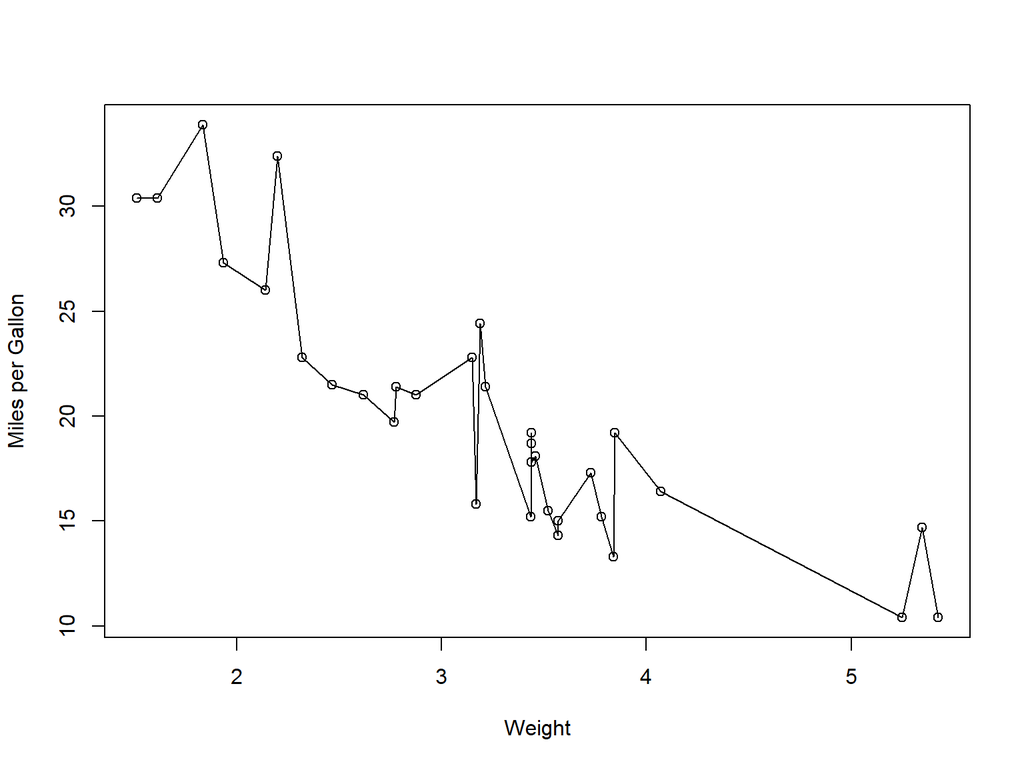

```r
myorder <- order(mtcars$wt)
plot(mtcars$wt[myorder], mtcars$mpg[myorder], type="o", xlab="Weight", ylab="Miles per Gallon")
```

更进一步地，对一个数据框，在排序时可以指定多个排序字段（称为多重排序）。例如，对数据框mtcars，我们先根据mpg列排序，当两行的mpg值相同时，再根据wt列排序，则代码为：

```r
newcars <- mtcars[order(mtcars$mpg, mtcars$wt),]
head(newcars)
```

```
##                      mpg cyl disp  hp drat    wt  qsec vs am gear carb
## Cadillac Fleetwood  10.4   8  472 205 2.93 5.250 17.98  0  0    3    4
## Lincoln Continental 10.4   8  460 215 3.00 5.424 17.82  0  0    3    4
## Camaro Z28          13.3   8  350 245 3.73 3.840 15.41  0  0    3    4
## Duster 360          14.3   8  360 245 3.21 3.570 15.84  0  0    3    4
## Chrysler Imperial   14.7   8  440 230 3.23 5.345 17.42  0  0    3    4
## Maserati Bora       15.0   8  301 335 3.54 3.570 14.60  0  1    5    8
```

Do It Yourself

对向量进行排序是非常常用的操作，如果只想要排序后的结果，可以使用函数`sort()`。

```r
a <- c(10, 9, 11, 7)

a[order(a, decreasing=TRUE)]
## [1] 11 10  9  7

sort(a, decreasing=TRUE)  #直接输出排序结果。该函数不能进行多重排序
## [1] 11 10  9  7
```

函数`rank(x)`可计算出各元素在排序后的名次，默认为升序排序。

```r
a <- c(10, 9, 11, 7)
rank(a)   #升序排序，10排第3位，9排第2位，11排第4位，7排第1位（最小）
## [1] 3 2 4 1

a[rank(a)<=2]  #找出a最小的2个元素
## [1] 9 7

a <- c(10, 9, 11, 10)   #如果有相等的元素，那么相等的元素构成一个tie
rank(a, ties.method="min")   #一个tie的各元素的序号由ties.method决定
## [1] 2 1 4 2

#tie.method可取"average", "first", "last", "random", "max", "min"之一
```

## 数据集的合并

把多个行数相同的数据框合并（即进行**列合并**）的方法是：

newdata <- cbind(data1, data2, …)

`cbind()`在合并时只要求`data1, data2, ...`具有相同的行数，在合并时，只是简单地把各列拼接起来。

```r
workerID <- c(1:4)
workerAge <- c(22, 25, 20, 21)
data1 <- data.frame(workerID, workerAge)

workerName <- c("Zhao", "Qian", "Sun", "Li")
workerGender <- c("Male", "Male", "Female", "Male")
data2 <- data.frame(workerName, workerGender)

mydata <- cbind(data1, data2)
mydata
```

```
##   workerID workerAge workerName workerGender
## 1        1        22       Zhao         Male
## 2        2        25       Qian         Male
## 3        3        20        Sun       Female
## 4        4        21         Li         Male
```

可见，在用`cbind()`合并时，各数据框中**行的顺序**要一致。

更安全的**列合并**方式是使用函数`merge()`，这个函数在合并时使用一个关键字列，语法是：

newdata <- merge(data1, data2, by=KeyCol)

其中，`KeyCol`是data1和data2都有的列，以该列为合并的依据。data1和data2中行的顺序可以不一致。

```r
workerID <- c(1:4)
workerAge <- c(22, 25, 20, 21)
data1 <- data.frame(workerID, workerAge)

workerID <- c(4:1)
workerName <- c("Zhao", "Qian", "Sun", "Li")
workerGender <- c("Male", "Male", "Female", "Male")
data2 <- data.frame(workerID,workerName, workerGender)

mydata <- merge(data1, data2, by="workerID")
mydata
```

```
##   workerID workerAge workerName workerGender
## 1        1        22         Li         Male
## 2        2        25        Sun       Female
## 3        3        20       Qian         Male
## 4        4        21       Zhao         Male
```

另外，merge()还可以合并不完全对齐的数据，语法是：

newdata <- merge(data1, data2, by.x=key1, by.y=key2, all.x | all.y | all)

其中，key1是data1的列，key2是data2的列，在合并时将使用这两个列的数据作为关键字；all.x、all.y、all可任选一个设置为TRUE。

merge()会首先计算出data1和data2的笛卡尔积，然后根据all.x、all.y或all的值从笛卡尔积中挑选出一部分数据：

- all.x=TRUE，表示data1的行将全部保留下来，这种操作也称为left join；
- all.y=TRUE，表示data2的行将全部保留下来，这种操作也称为right join；
- all=TRUE，表示两个数据框的数据都将被保留；
- 如果以上三个参数都未使用，那么只会保留在data1和data2都出现的行。

```r
workerName <- c("a", "b", "c", "d")
workerAge <- c(23, 22, 22, 25)
data1 <- data.frame(workerName, workerAge)

anotherName <- c("c", "d", "e")
anotherSalary <- c(2200, 2500, 2000)
data2 <- data.frame(anotherName, anotherSalary)

merge(data1, data2, by.x="workerName", by.y="anotherName", all.x=TRUE)
```

```
##   workerName workerAge anotherSalary
## 1          a        23            NA
## 2          b        22            NA
## 3          c        22          2200
## 4          d        25          2500
```

```r
merge(data1, data2, by.x="workerName", by.y="anotherName", all.y=TRUE)
```

```
##   workerName workerAge anotherSalary
## 1          c        22          2200
## 2          d        25          2500
## 3          e        NA          2000
```

```r
merge(data1, data2, by.x="workerName", by.y="anotherName", all=TRUE)
```

```
##   workerName workerAge anotherSalary
## 1          a        23            NA
## 2          b        22            NA
## 3          c        22          2200
## 4          d        25          2500
## 5          e        NA          2000
```

```r
merge(data1, data2, by.x="workerName", by.y="anotherName")
```

```
##   workerName workerAge anotherSalary
## 1          c        22          2200
## 2          d        25          2500
```

注意：`merge()`在合并两个数据框时，会将by.x和by.y合并成一列，在合并结果中这一列被命名为by.x的值。请观察上面的例子。

使用函数`merge()`进行左连接（或右连接）常用于将分散的多个小数据集整合成一个完整的大数据集。例如：

```r
student <- data.frame(
  studentName=c("Liu", "Zhang", "Cheng", "Wang", "Li"),
  home=c("WH", "BJ", "WH", "SH", "WH"),    #学生的户籍地（简称）
  stringsAsFactors = FALSE
)

city <- data.frame(
  cityName=c("WH", "BJ", "SH", "GZ"),
  fullName=c("Wuhan", "Beijing", "Shanghai", "Guangzhou"),
  stringsAsFactors = FALSE
)

#将每个学生的户籍地由简称翻译成全称
student2 <- merge(student, city, by.x="home", by.y="cityName", all.x=TRUE)
student2
##   home studentName fullName
## 1   BJ       Zhang  Beijing
## 2   SH        Wang Shanghai
## 3   WH         Liu    Wuhan
## 4   WH       Cheng    Wuhan
## 5   WH          Li    Wuhan
```

将两个具有相同列的数据框合并（即进行**行合并**）的方法是：

newdata <- rbind(data1, data2, …)

其中，`data1、data2、...`的列结构相同，即列数相同，且各列的名字也相同。

```r
workerID <- c(1:4)
workerName <- c("Zhao", "Qian", "Sun", "Li")
data1 <- data.frame(workerID, workerName)

workerID <- c(5:7)
workerName <- c("Zhou", "Wu", "Zheng")
data2 <- data.frame(workerID, workerName)

mydata <- rbind(data1, data2)
mydata
```

```
##   workerID workerName
## 1        1       Zhao
## 2        2       Qian
## 3        3        Sun
## 4        4         Li
## 5        5       Zhou
## 6        6         Wu
## 7        7      Zheng
```

## 提取数据子集

从一个数据框中提取出部分行（或列），可以用行（或列）的下标，也可以使用逻辑向量。

```r
mydata <- mtcars[c("mpg", "wt")]; head(mydata)
```

```
##                    mpg    wt
## Mazda RX4         21.0 2.620
## Mazda RX4 Wag     21.0 2.875
## Datsun 710        22.8 2.320
## Hornet 4 Drive    21.4 3.215
## Hornet Sportabout 18.7 3.440
## Valiant           18.1 3.460
```

```r
mydata <- mtcars[mtcars$wt>5,]; mydata
```

```
##                      mpg cyl disp  hp drat    wt  qsec vs am gear carb
## Cadillac Fleetwood  10.4   8  472 205 2.93 5.250 17.98  0  0    3    4
## Lincoln Continental 10.4   8  460 215 3.00 5.424 17.82  0  0    3    4
## Chrysler Imperial   14.7   8  440 230 3.23 5.345 17.42  0  0    3    4
```

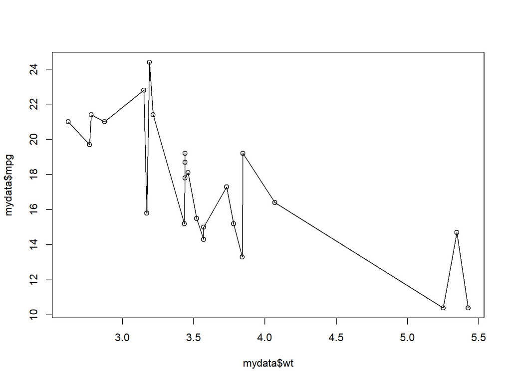

```r
mydata <- mtcars[mtcars$wt>2.5 & mtcars$mpg>10, c("wt","mpg")]
mydata <- mydata[order(mydata$wt),]
plot(mydata$wt, mydata$mpg, type="o")
```

提取数据子集还可以使用函数`subset()`，语法为：

newdata <- subset(mydata, condition, select=columns)

其中，在`condition`参数中可以直接使用列名，不需要再使用`$`操作符。如果不使用`select`参数，那么将提取出所有的列。

```r
newdata <- subset(mtcars, wt>2.5 & drat<3, select=c(wt, mpg))
newdata
```

```
##                      wt  mpg
## Valiant            3.46 18.1
## Cadillac Fleetwood 5.25 10.4
## Dodge Challenger   3.52 15.5
```

**随机抽样**

在正式分析大数据集之前，通常需要先抽取一个小样本进行实验。随机抽样会用到三个函数：`nrow()、sample()和set.seed()`。函数`nrow()`返回数据框的行数，语法为：

n <- nrow(mydata)

函数`sample()`用于从一个向量中随机抽取出若干个元素，语法为：

myset <- sample(vector, n, replace=FALSE)

该函数会从向量vector中随机抽取出n个元素，参数`replace=TRUE`表示进行放回抽样，`replace=FALSE`表示进行不放回抽样，默认进行不放回抽样。

```r
nrow(mtcars)  #数据框mtcars共有32行
```

```
## [1] 32
```

```r
sample(1:32, 5)
```

```
## [1] 19 20 21 29  8
```

```r
sample(1:32, 5)
```

```
## [1] 30  3  5 19 20
```

```r
a <- sample(1: nrow(mtcars), 5)
mydata <- mtcars[a, ]  #从mtcars中随机抽取5行
mydata
```

```
##                   mpg cyl  disp  hp drat    wt  qsec vs am gear carb
## Pontiac Firebird 19.2   8 400.0 175 3.08 3.845 17.05  0  0    3    2
## Mazda RX4 Wag    21.0   6 160.0 110 3.90 2.875 17.02  0  1    4    4
## Merc 280C        17.8   6 167.6 123 3.92 3.440 18.90  1  0    4    4
## Hornet 4 Drive   21.4   6 258.0 110 3.08 3.215 19.44  1  0    3    1
## Duster 360       14.3   8 360.0 245 3.21 3.570 15.84  0  0    3    4
```

函数`sample()`进行抽样时，在内部会用到随机数。

计算机上得到的随机数是一种根据**算法**计算出的数值序列，并不是真正的随机数，因此称为伪随机数。这种伪数据数序列是由**算法和初始种子**来决定的，因此我们可以通过指定初始种子，来决定随机数序列。

设置随机数种子的函数是：

set.seed(n)

通过设置随机数种子，我们可以让`sample()`的抽样结果可重现(reproducible)。

```r
set.seed(23)
mydata <- mtcars[sample(1: nrow(mtcars), 5), ]  #从mtcars中随机抽取5行
mydata
```

```
##                mpg cyl  disp  hp drat    wt  qsec vs am gear carb
## Honda Civic   30.4   4  75.7  52 4.93 1.615 18.52  1  1    4    2
## Duster 360    14.3   8 360.0 245 3.21 3.570 15.84  0  0    3    4
## Merc 280      19.2   6 167.6 123 3.92 3.440 18.30  1  0    4    4
## Toyota Corona 21.5   4 120.1  97 3.70 2.465 20.01  1  0    3    1
## AMC Javelin   15.2   8 304.0 150 3.15 3.435 17.30  0  0    3    2
```

## 基本数据管理操作

对于一个数据框，我们要学会：

- 创建新的列变量
- 删除列变量
- 列变量的重编码
- 列变量的重命名
- 处理缺失值
- 处理日期值
- 数据类型转换
- 数据排序
- 数据集的合并
- 提取数据子集